# Outlier Detection - One class Classificatio

- Outlier samples → sparse, minoritary, category
- Outlier scenario → multi-class scenario + more than one class
- One-class classifification → single class
- Single class → model its boundary + isolate the “rest”
- Non-single-class samples → non-modeled

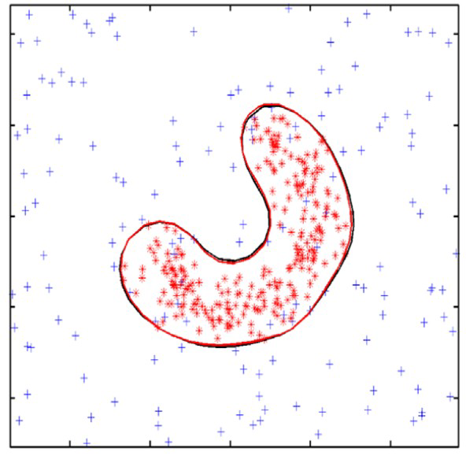

Outlier Detection

# Spambase Dataset

- Choose a supervised dataset (e.g. spambase)
- Choose one of its classes (e.g. “non-spam e-mails”)
- Apply the one-class method over it
- Be careful, methods may only work with numerical features. Remove the class!
- Graph “outlierness” distribution → cut-off point to decide outliers
- Are there suspicious outliers within this class e-mails?

```r
spambase = read.csv(file="../data/spambase.csv", header=TRUE, sep=",")
spambase$class = as.factor(spambase$class)
spambaseNONSPAM = spambase[spambase$class == 0,]
spambaseNONSPAM = spambaseNONSPAM[,-58]
print(spambaseNONSPAM)
```

|  | word_freq_make | word_freq_address | word_freq_all | word_freq_3d | word_freq_our | word_freq_over | word_freq_remove | word_freq_internet | word_freq_order | word_freq_mail | word_freq_receive | word_freq_will | word_freq_people | word_freq_report | word_freq_addresses | word_freq_free | word_freq_business | word_freq_email | word_freq_you | word_freq_credit | word_freq_your | word_freq_font | word_freq_000 | word_freq_money | word_freq_hp | word_freq_hpl | word_freq_george | word_freq_650 | word_freq_lab | … |
| --- | --- | --- | --- | --- | --- | --- | --- | --- | --- | --- | --- | --- | --- | --- | --- | --- | --- | --- | --- | --- | --- | --- | --- | --- | --- | --- | --- | --- | --- | --- |
| 1814 | 0.00 | 0.00 | 0.00 | 0.00 | 0.00 | 0.00 | 0.00 | 0.00 | 0.00 | 0.00 | 0.00 | 0.00 | 0.00 | 0.00 | 0.00 | 0.00 | 0.00 | 0.00 | 0.00 | 0.00 | 0.00 | 0.00 | 0.00 | 0.00 | 0.00 | 0.00 | 0.00 | 0.00 | 0.00 | … |
| 1815 | 0.00 | 0.00 | 0.00 | 0.00 | 0.00 | 0.00 | 0.00 | 0.00 | 0.00 | 0.85 | 0.00 | 0.00 | 0.00 | 0.00 | 1.70 | 0.00 | 0.00 | 0.00 | 2.56 | 0.00 | 1.70 | 0.00 | 0.00 | 0.00 | 0.00 | 0.00 | 0.00 | 0.00 | 0.00 | … |
| 1816 | 0.00 | 0.00 | 0.00 | 0.00 | 0.00 | 0.00 | 0.00 | 0.00 | 0.00 | 0.00 | 0.00 | 0.00 | 0.00 | 0.00 | 0.00 | 0.00 | 0.00 | 0.00 | 0.00 | 0.00 | 0.00 | 0.00 | 0.00 | 0.00 | 0.00 | 0.00 | 33.33 | 0.00 | 0.00 | … |
| 1817 | 0.00 | 0.00 | 0.00 | 0.00 | 0.00 | 0.00 | 0.00 | 0.00 | 0.00 | 0.00 | 0.00 | 0.00 | 0.00 | 0.00 | 0.00 | 0.00 | 0.00 | 0.00 | 0.00 | 0.00 | 0.00 | 0.00 | 0.00 | 0.00 | 5.12 | 0.00 | 0.00 | 0.00 | 0.00 | … |
| 1818 | 0.00 | 0.00 | 0.00 | 0.00 | 0.00 | 0.00 | 0.00 | 0.00 | 0.00 | 0.00 | 0.00 | 0.00 | 0.00 | 0.00 | 0.00 | 0.00 | 0.00 | 0.00 | 0.00 | 0.00 | 0.00 | 0.00 | 0.00 | 0.00 | 0.00 | 0.00 | 0.07 | 0.00 | 0.07 | … |
| 1819 | 0.00 | 0.00 | 0.00 | 0.00 | 2.04 | 0.00 | 0.00 | 0.00 | 0.00 | 0.00 | 0.00 | 0.00 | 0.00 | 0.00 | 0.00 | 0.00 | 0.00 | 0.00 | 0.00 | 0.00 | 0.00 | 0.00 | 0.00 | 0.00 | 4.08 | 2.04 | 2.04 | 2.04 | 2.04 | … |
| 1820 | 0.00 | 0.00 | 0.00 | 0.00 | 0.00 | 0.00 | 0.00 | 0.00 | 0.00 | 0.00 | 0.00 | 0.00 | 0.00 | 0.00 | 0.00 | 0.00 | 0.00 | 0.00 | 0.00 | 0.00 | 0.00 | 0.00 | 0.00 | 0.00 | 0.00 | 0.00 | 0.84 | 0.00 | 0.84 | … |
| 1821 | 0.00 | 0.00 | 0.00 | 0.00 | 0.00 | 0.00 | 0.00 | 0.00 | 0.00 | 0.00 | 0.00 | 0.00 | 0.00 | 0.00 | 0.00 | 0.00 | 0.00 | 0.00 | 0.00 | 0.00 | 0.00 | 0.00 | 0.00 | 0.00 | 0.00 | 0.00 | 0.00 | 0.00 | 0.00 | … |
| 1822 | 0.00 | 0.00 | 0.00 | 0.00 | 0.00 | 0.00 | 0.00 | 0.00 | 0.00 | 0.00 | 0.00 | 0.00 | 0.00 | 0.00 | 0.00 | 0.00 | 0.00 | 0.00 | 7.31 | 0.00 | 0.00 | 0.00 | 0.00 | 0.00 | 0.00 | 0.00 | 0.00 | 0.00 | 0.00 | … |
| 1823 | 0.00 | 0.00 | 0.00 | 0.00 | 0.00 | 0.00 | 0.00 | 0.00 | 0.00 | 0.00 | 0.00 | 0.00 | 0.00 | 0.00 | 0.00 | 0.00 | 0.00 | 0.00 | 4.00 | 0.00 | 0.00 | 0.00 | 0.00 | 0.00 | 0.00 | 0.00 | 0.00 | 0.00 | 0.00 | … |

[output cut: 990 more lines]

# Isolation Forest

- Compute “isolation score” per sample
- Construct a tree per sample
- Random splits on attribute values
- → isolates the sample from the rest
- → “outliers easy to isolate…”
- Path length from root to node
- ~ “isolation score” = “outlierness”
- “low path length” ~ “high outlierness”
- → easy to isolate point
- → graph “outlierness” values → threshold

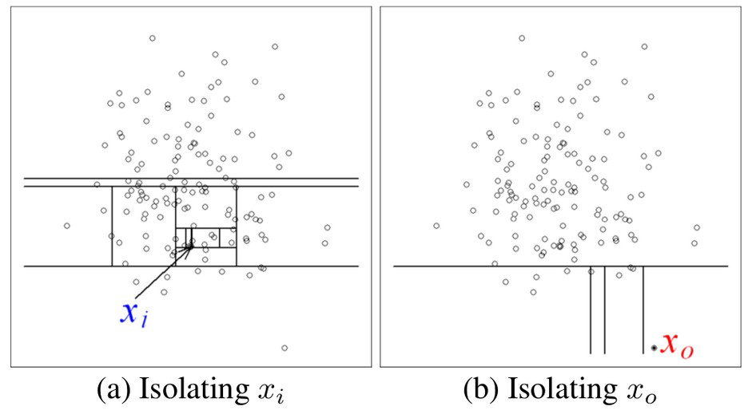

Isolation Forest

```r
# Package with IsolationForest implementation
library(solitude)

# Empty tree structure
iso <- isolationForest$new()

# Learn the IsolationForest for our data
iso$fit(spambaseNONSPAM)
```

```
INFO  [15:58:34.958] dataset has duplicated rows
INFO  [15:58:34.977] Building Isolation Forest ...
INFO  [15:58:35.146] done
INFO  [15:58:35.163] Computing depth of terminal nodes ...
INFO  [15:58:35.869] done
INFO  [15:58:35.986] Completed growing isolation forest
```

```r
p <- iso$predict(spambaseNONSPAM)
#print(p)
sort(p$anomaly_score)
```

```
   [1] 0.5820092 0.5820092 0.5820092 0.5820092 0.5820092 0.5820092 0.5820092 0.5820092 0.5820092
  [10] 0.5820092 0.5820092 0.5820092 0.5820092 0.5820092 0.5820092 0.5820092 0.5820092 0.5820092
  [19] 0.5820092 0.5820092 0.5820092 0.5820092 0.5820092 0.5820092 0.5820092 0.5820092 0.5820092
  [28] 0.5820092 0.5820092 0.5820092 0.5820092 0.5820092 0.5820092 0.5820092 0.5820092 0.5820092
  [37] 0.5820092 0.5820092 0.5820092 0.5820092 0.5820092 0.5820092 0.5820092 0.5820092 0.5820092
  [46] 0.5820092 0.5820092 0.5820092 0.5820092 0.5820092 0.5820092 0.5820092 0.5820092 0.5820092
  [55] 0.5820092 0.5820092 0.5820092 0.5820092 0.5820092 0.5820092 0.5820092 0.5820092 0.5820092
  [64] 0.5820092 0.5820092 0.5820092 0.5820092 0.5820092 0.5820092 0.5820092 0.5820092 0.5820092
  [73] 0.5820092 0.5820092 0.5820092 0.5820092 0.5820092 0.5820092 0.5820092 0.5820092 0.5820092
  [82] 0.5820092 0.5820092 0.5820092 0.5820092 0.5820092 0.5820092 0.5820092 0.5820092 0.5820092
  [91] 0.5820092 0.5820092 0.5820092 0.5820092 0.5820092 0.5820092 0.5820092 0.5820092 0.5820092
 [100] 0.5820092 0.5820092 0.5820092 0.5820092 0.5820092 0.5820092 0.5820092 0.5820092 0.5820092
 [109] 0.5820092 0.5820092 0.5820092 0.5820092 0.5820092 0.5820092 0.5820092 0.5820092 0.5820092
 [118] 0.5820092 0.5820092 0.5820092 0.5820092 0.5820092 0.5820092 0.5820092 0.5820092 0.5820092
 [127] 0.5820092 0.5820092 0.5820092 0.5820092 0.5820092 0.5820092 0.5820092 0.5820092 0.5820092
```

[output cut: 98 more lines]

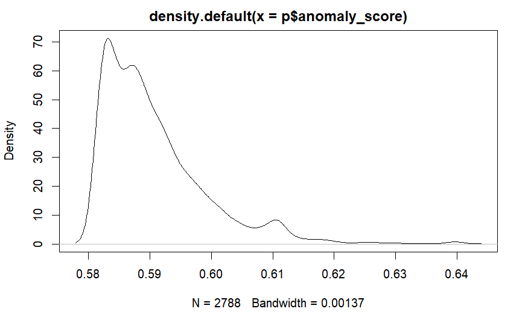

```r
plot(density(p$anomaly_score))
```

```r
# Base don the plot, decide the cut-off point (e.g > 0.63)
which(p$anomaly_score > 0.63)
```

```
[1]  152  762  818  884 1105 1162 1433 1460 1551
```

# OneClass SVM (OCSVM)

- Learn a SVM with single-class samples
- Map to higher dimension space
- Separating hyperplane
- Maximize margin between origin and data
- Outliers → points outside boundary

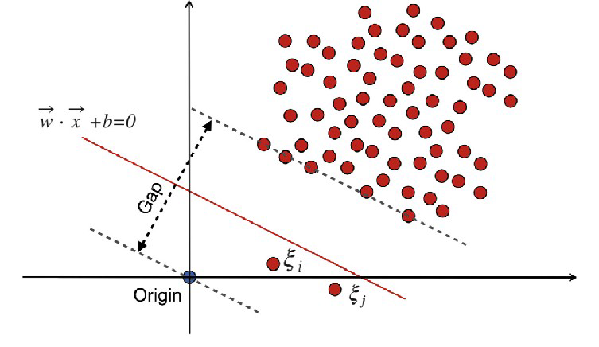

OneClass SVMs (OCSVM)

```r
library(e1071)

df <- spambaseNONSPAM

# train a SVM one-classification model
model <-svm(df, y=NULL, type='one-classification')
summary(model)
```

```
Call:
svm.default(x = df, y = NULL, type = "one-classification")


Parameters:
   SVM-Type:  one-classification
 SVM-Kernel:  radial
      gamma:  0.01754386
         nu:  0.5

Number of Support Vectors:  1395




Number of Classes: 1
```

```r
# CAUTION: testing on the same training set
# TRUE values mean suspect outliers
pred <- predict(model, df)
which(pred == TRUE)
```

```
1820 1821 1823 1825 1827 1828 1831 1832 1834 1836 1837 1841 1842 1845 1846 1847 1850 1851 1853
   7    8   10   12   14   15   18   19   21   23   24   28   29   32   33   34   37   38   40
1855 1856 1857 1864 1865 1866 1868 1871 1872 1875 1877 1878 1880 1882 1884 1886 1887 1888 1889
  42   43   44   51   52   53   55   58   59   62   64   65   67   69   71   73   74   75   76
1890 1895 1896 1898 1899 1902 1904 1905 1909 1910 1911 1912 1913 1915 1916 1917 1928 1937 1938
  77   82   83   85   86   89   91   92   96   97   98   99  100  102  103  104  115  124  125
1939 1942 1943 1944 1945 1947 1948 1949 1952 1953 1954 1955 1956 1958 1960 1962 1964 1967 1969
 126  129  130  131  132  134  135  136  139  140  141  142  143  145  147  149  151  154  156
1971 1972 1975 1979 1981 1982 1990 1991 1996 1997 2000 2002 2004 2007 2009 2013 2016 2018 2020
 158  159  162  166  168  169  177  178  183  184  187  189  191  194  196  200  203  205  207
2022 2023 2024 2025 2026 2027 2029 2030 2031 2032 2033 2035 2036 2037 2039 2043 2044 2046 2049
 209  210  211  212  213  214  216  217  218  219  220  222  223  224  226  230  231  233  236
2051 2052 2058 2063 2064 2068 2069 2070 2071 2079 2080 2081 2083 2085 2086 2088 2089 2091 2092
 238  239  245  250  251  255  256  257  258  266  267  268  270  272  273  275  276  278  279
2093 2096 2097 2098 2099 2100 2101 2102 2103 2104 2105 2109 2113 2114 2118 2122 2124 2125 2126
```

[output cut: 92 more lines]

```r
table(pred)
```

```
pred
FALSE  TRUE
 1413  1375
```

# Local Outlier Factor (LOF)

- Distance-based algorithm
- To decide “outlier”
- → by local neighborhood
- → by local density
- Parameter → k, number of neighbours
- Calculate the neighborhood
- Outlier → defifined “locally”
- Outlierness → compute density of its local k-neighborhood

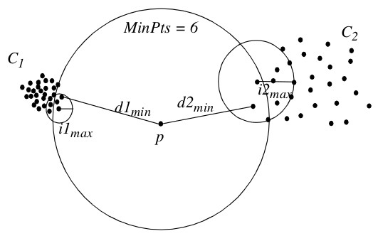

Local Outlier Factor (LOF)

```r
library(DDoutlier)

# calculate "outlierness" score, by LOF
outlierness = LOF(dataset=spambaseNONSPAM, k=5)

# assign an index to outlierness values
names(outlierness) <- 1:nrow(spambaseNONSPAM)
sort(outlierness, decreasing=TRUE)
```

```
        88        152        277        313        410        753        780        784
       Inf        Inf        Inf        Inf        Inf        Inf        Inf        Inf
       801        857        980       1217       1237       1387       1416       1426
       Inf        Inf        Inf        Inf        Inf        Inf        Inf        Inf
      1434       1591       1726       1790       1794       1799       1827       1832
       Inf        Inf        Inf        Inf        Inf        Inf        Inf        Inf
      1864       1867       1994       2022       2025       2100       2492       2581
       Inf        Inf        Inf        Inf        Inf        Inf        Inf        Inf
      2583       2721       2725       2734        724        652       1804       1706
       Inf        Inf        Inf        Inf 126.753753  40.631664  13.730299  12.900168
         1       1584        202       1373       2651       1353       2033       1601
  8.682133   8.421207   8.110102   7.603172   6.893322   5.384038   4.803091   4.602546
      2655       1659        297        719        248        344       2432       1566
  4.299674   4.243585   4.242413   3.973940   3.825549   3.580432   3.351919   3.221447
      1145       1491        649       1662          3        375        929       2101
  3.183175   3.076260   3.072096   3.019287   2.936765   2.936765   2.936765   2.936765
      1999       1576       1074       1075        907       1346       1914        201
  2.864863   2.828074   2.801082   2.791692   2.728091   2.691439   2.680174   2.618742
      2057       2192       2228        792       2574       2507       1597        668
  2.577734   2.561513   2.552358   2.528558   2.524053   2.523666   2.495377   2.493499
      1596        306       1948       1860       2748       1679       1146       2429
  2.412371   2.390392   2.352003   2.348006   2.344273   2.330613   2.280939   2.250109
      1423       1249       2278       1537       1538       2186        696        941
  2.244388   2.237461   2.221767   2.196531   2.196531   2.183604   2.181753   2.181753
      1338       1024        563       1184       2032       2290        165       2709
  2.165907   2.150594   2.119139   2.113190   2.104800   2.104309   2.077841   2.065242
      1684       2605       2194       1201         11        241       1595        809
  2.060070   2.058128   2.032645   2.030404   2.022375   2.021056   2.010931   1.988485
      2395        739        311       2731       1722        709       1106       1658
  1.974032   1.973701   1.972074   1.945570   1.939486   1.934920   1.934484   1.934478
      1500        617       1170       1228       2534       2010        348        886
  1.929202   1.927819   1.922777   1.917790   1.917790   1.908455   1.907476   1.906584
      2726       1588       1861       2647       1092        356       1153        887
  1.894491   1.883120   1.872009   1.867455   1.853840   1.850062   1.848580   1.847377
      2191       2134        557       2270       1020       1824       2131       1093
  1.846369   1.842269   1.835187   1.828270   1.828127   1.819852   1.819017   1.817577
       927        490       1762       1678       1232       1341        364       2150
  1.809315   1.804606   1.803544   1.801941   1.798899   1.796993   1.794264   1.792751
      1139       1141        603       2218       1177       2226       2434       2560
  1.790215   1.790215   1.786195   1.783428   1.777930   1.775743   1.775334   1.773333
```

[output cut: 196 more lines]

```
      2116       2524        861        192       1891       2417       2618        734
  1.139908   1.139769   1.139640   1.139364   1.138993   1.138981   1.138967   1.138704
      2061       2461        950       1357         70       1442        441        365
  1.138168   1.137877   1.137793   1.137751   1.137614   1.137375   1.136897   1.136853
      2130        155        485        452       2600       1715        347       1671
  1.136794   1.136771   1.136573   1.136542   1.136286   1.136027   1.135929   1.135918
      2221       1743        600       1419       2114        934       1079       2464
  1.135732   1.135551   1.135506   1.135419   1.134583   1.134355   1.133962   1.133821
      1939       2490       1536        430        551        326        505        701
  1.133474   1.133473   1.133113   1.133094   1.132837   1.132754   1.132026   1.131952
       718        178         25       1157        721        746       1882       1013
  1.131952   1.131931   1.131418   1.131286   1.131248   1.131123   1.130034   1.128655
      2108       1441       1071       1978       2493       2232       1883       1495
  1.128196   1.128129   1.128059   1.127627   1.127492   1.127243   1.127066   1.126159
 [ reached getOption("max.print") -- omitted 1621 entries ]
```

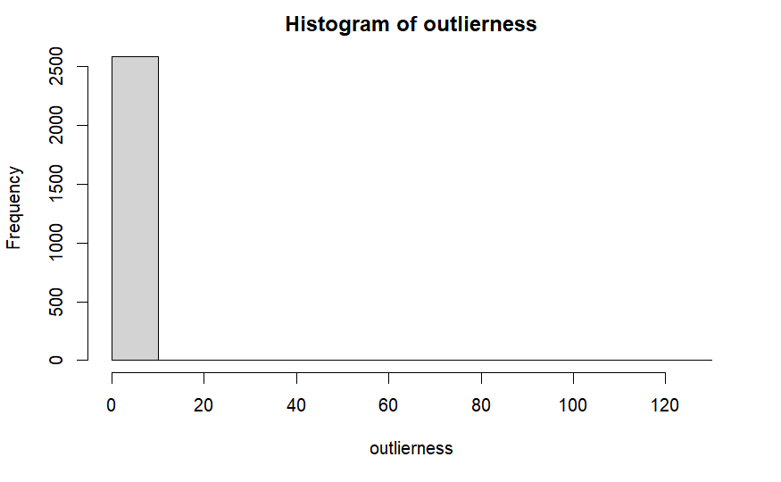

```r
hist(outlierness)
```

```r
which(outlierness > 20.0)
```

```
  88  152  277  313  410  652  724  753  780  784  801  857  980 1217 1237 1387 1416 1426 1434
  88  152  277  313  410  652  724  753  780  784  801  857  980 1217 1237 1387 1416 1426 1434
1591 1726 1790 1794 1799 1827 1832 1864 1867 1994 2022 2025 2100 2492 2581 2583 2721 2725 2734
1591 1726 1790 1794 1799 1827 1832 1864 1867 1994 2022 2025 2100 2492 2581 2583 2721 2725 2734
```

# Autoencoder

- Learn representation of data
- Reducing to non-linear dimensions in hidden layers
- {Encode + Decode} 1-class data
- Check for anomalies
- Does the autoencoder “reconstruct” the input data in the output?
- → “reconstruction error”
- → high value indicative of outlierness
- Hidden layers’ features
- Compact, non-linear representation
- → learn with them a supervised model?

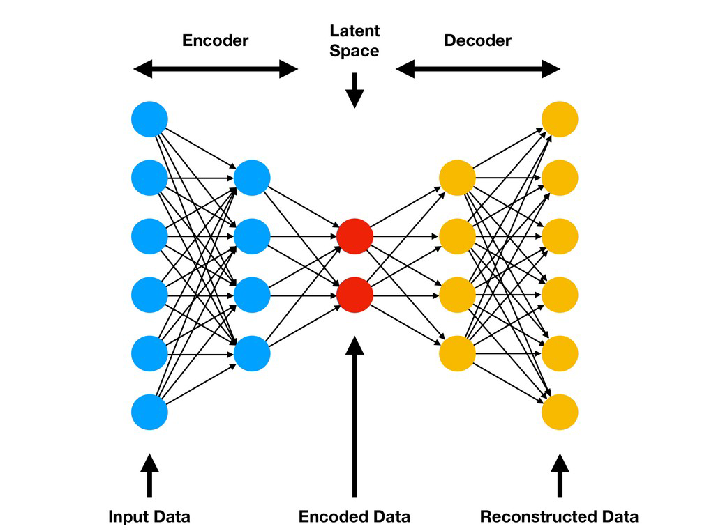

Autoencoder

```r
library(h2o)
h2o.init(port = 50001)
```

[output not shown]

```r
spambase = h2o.importFile(path = "../data/spambase.csv")
spambaseNONSPAM = spambase[spambase$C58 == 0,]
spambaseNONSPAM = spambaseNONSPAM[,-58]
colnames(spambaseNONSPAM)
```

```
 [1] "word_freq_make"
 [2] "word_freq_address"
 [3] "word_freq_all"
 [4] "word_freq_3d"
 [5] "word_freq_our"
 [6] "word_freq_over"
 [7] "word_freq_remove"
 [8] "word_freq_internet"
 [9] "word_freq_order"
[10] "word_freq_mail"
[11] "word_freq_receive"
[12] "word_freq_will"
[13] "word_freq_people"
[14] "word_freq_report"
[15] "word_freq_addresses"
```

[output cut: 42 more lines]

```r
dim(spambaseNONSPAM)
```

```
[1] 2788   57
```

```r
# learn autoencoder with 2 hidden layers of 10 units each
autoencoder_model = h2o.deeplearning(x=1:57,
                                     training_frame=spambaseNONSPAM,
                                     autoencoder=TRUE,
                                     hidden=c(10,10),
                                     epochs=5)
# features in the autoencoder's first hidden layer
deep_features_layer1 = h2o.deepfeatures(autoencoder_model, spambaseNONSPAM, layer=1)
# further supervised models can be trained with these features
head(deep_features_layer1)
```

|  | DF.L1.C1 | DF.L1.C2 | DF.L1.C3 | DF.L1.C4 | DF.L1.C5 | DF.L1.C6 | DF.L1.C7 | DF.L1.C8 | DF.L1.C9 | DF.L1.C10 |
| --- | --- | --- | --- | --- | --- | --- | --- | --- | --- | --- |
| 1 | 0.5042701 | 1.503364 | 1.1454224 | 0.6051735 | 2.632304 | 1.498169 | 1.516800 | 0.5320410 | 0.00000000 | 2.281528 |
| 2 | 0.4608570 | 1.497150 | 0.9937403 | 0.4603132 | 2.869020 | 1.884739 | 1.737389 | 0.7307566 | 0.06242488 | 2.283224 |
| 3 | 1.4415526 | 2.653371 | 2.4177979 | 0.8134699 | 2.020532 | 2.464531 | 2.765053 | 0.0000000 | 0.01274781 | 1.137774 |
| 4 | 0.9474659 | 1.785937 | 1.4677024 | 0.7135409 | 2.598370 | 1.965911 | 1.989583 | 0.4776006 | 0.14631221 | 1.954439 |
| 5 | 0.7997336 | 1.682176 | 1.3461418 | 0.5368279 | 2.771408 | 1.783492 | 1.881423 | 0.5163093 | 0.00000000 | 2.158412 |
| 6 | 1.8695658 | 1.565380 | 1.9322929 | 1.5291026 | 1.685871 | 2.682550 | 2.650587 | 0.7113701 | 1.02194058 | 1.137554 |

```r
# reconstruction error per sample ~ outlierness indicative
reconstruction_error = h2o.anomaly(autoencoder_model, spambaseNONSPAM)
head(reconstruction_error)
```

|  | Reconstruction.MSE |
| --- | --- |
| 1 | 0.017009993 |
| 2 | 0.010723456 |
| 3 | 0.016639546 |
| 4 | 0.002353341 |
| 5 | 0.001948545 |
| 6 | 0.017292327 |

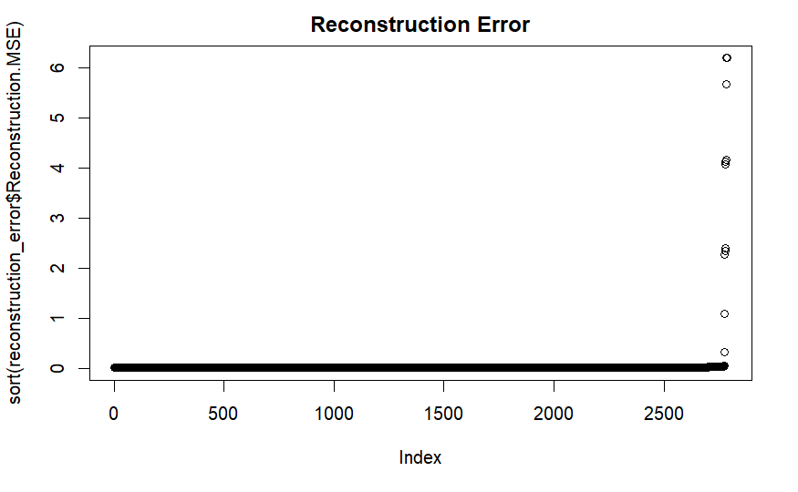

```r
reconstruction_error = as.data.frame(reconstruction_error)
plot(sort(reconstruction_error$Reconstruction.MSE), main="Reconstruction Error")
```

```r
which(reconstruction_error > 0.02)
```

```
 [1]   66  110  152  202  241  458  466  515  671  673  742  762  768  802  818  861  884  910
[19]  990 1005 1036 1103 1139 1141 1162 1163 1193 1220 1366 1413 1433 1434 1438 1460 1491 1500
[37] 1551 1596 1611 1625 1662 1678 1719 1723 1749 1750 1755 1953 1976 2010 2043 2067 2094 2100
[55] 2207 2208 2227 2453 2454 2455 2456 2457 2461 2463 2490 2496 2497 2500 2507 2566 2651
```